# PROB 2.14

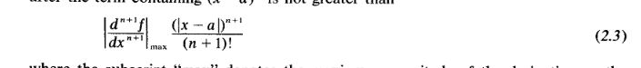

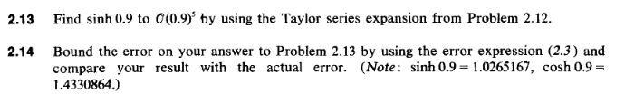

### 문제 2.3 - $ e^{0.5} $의 테일러 급수 근사와 오차 항

#### 1. 테일러 급수 계산

$ x = 0.5 $로 계산하고 $ \sigma(0.5)^3 $까지만 포함하면: $$ e^{0.5} = 1 + \frac{0.5^1}{1!} + \frac{0.5^2}{2!} + \frac{0.5^3}{3!} + \sigma(0.5)^4 $$ 각 항을 계산하면: $$ e^{0.5} \approx 1 + 0.5 + \frac{0.25}{2} + \frac{0.125}{6} = 1 + 0.5 + 0.125 + 0.0208333 = 1.6458333 $$

### 문제 2.13 - $ \sinh(0.9) $의 테일러 급수 근사와 오차 항

#### 1. 테일러 급수 정의

$ \sinh(x) $의 테일러 급수: $$ \sinh(x) = \sum_{n=0}^{\infty} \frac{x^{2n+1}}{(2n+1)!} $$

$ \sigma(x)^5 $까지의 근사를 위해, $ x = 0.9 $일 때: $$ \sinh(0.9) \approx 0.9 + \frac{(0.9)^3}{3!} + \frac{(0.9)^5}{5!} $$

$$ \sinh(0.9) \approx 0.9 + \frac{0.729}{6} + \frac{0.59049}{120} = 0.9 + 0.1215 + 0.00492 = 1.02642 $$

#### 2. 오차 항

$ f(x) = \sinh(x) $이고, $ \sinh(x) $의 도함수는 $ \cosh(x) $이다. $ \cosh(0.9) \approx 1.4330864 $이므로: $$ \sigma(0.9)^5 = \frac{(0.9)^7}{7!} \cdot 1.4330864 $$ $$ \sigma(0.9)^5 \approx \frac{0.4782969}{5040} \cdot 1.4330864 \approx 0.000136 $$ 따라서 오차 한계는 약 $ 0.000136 $.

# PROB 2.18

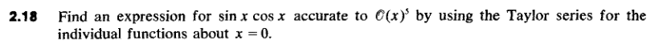

### 문제 2.18 - $ \sin(x) \cos(x) $의 테일러 급수 근사와 오차 항

**문제**: $ \sin(x) \cos(x) $에 대해 $ x = 0 $에서 $ \sigma(x)^5 $까지 근사식을 구하시오.

#### 1. 테일러 급수 정의

$ \sin(x) $와 $ \cos(x) $의 테일러 급수:

$$ \sin(x) = \sum_{n=0}^{\infty} \frac{(-1)^n x^{2n+1}}{(2n+1)!} $$ $$ \cos(x) = \sum_{n=0}^{\infty} \frac{(-1)^n x^{2n}}{(2n)!} $$

#### 2. 오차 항

이 근사의 오차 항은 $ \sigma(x)^7 $로 주어진다. 즉, $ n = 2 $에서 발생하는 오차 항은: $$ \sigma(x)^7 = \frac{|x - a|^{n+1}}{(n+1)!} \cdot \left| \frac{d^{n+1}(\sin(x)\cos(x))}{dx^{n+1}} \right|_{\text{max}} $$

여기서 $ \sin(x) \cos(x) $의 도함수들을 계산해 최대값을 구할 수 있다.

# PROB 3.24

### 문제 3.24 - 중앙 차분 표현식을 사용

#### 문제:

함수 $ f(x) $가 주어진 점 $ x_i $에서 $ \Delta f_i / h = 0.23751 $이고, $ \nabla f_i / h = 0.24369 $일 때, $ h = 0.1 $입니다. $ f'(x_i) $와 $ f''(x_i) $의 $ \sigma(h^2) $까지의 중앙 차분 표현식에 대한 수치 값을 구하시오.

#### 1. 중앙 차분 공식

1. **일차 도함수 $ f'(x_i) $** 에 대한 중앙 차분 공식: $$ f'(x_i) \approx \frac{f(x_{i+1}) - f(x_{i-1})}{2h} $$

$$ f'(x_i) \approx \frac{\Delta f_i + \nabla f_i}{2h} $$ 여기서:

- $ \Delta f_i = f(x_{i+1}) - f(x_i) $이고, $ \nabla f_i = f(x_i) - f(x_{i-1}) $
2. **이차 도함수 $ f''(x_i) $** 에 대한 중앙 차분 공식: $$ f''(x_i) \approx \frac{f(x_{i+1}) - 2f(x_i) + f(x_{i-1})}{h^2} $$ $$ f''(x_i) \approx \frac{\Delta f_i - \nabla f_i}{h^2} $$

#### 2. 주어진 값 대입

- $ \Delta f_i / h = 0.23751 $
- $ \nabla f_i / h = 0.24369 $
- $ h = 0.1 $

##### 1차 도함수 $ f'(x_i) $ 계산:

$$ f'(x_i) \approx \frac{(0.23751 \times 0.1) + (0.24369 \times 0.1)}{2 \times 0.1} $$ $$ f'(x_i) \approx \frac{0.023751 + 0.024369}{0.2} = \frac{0.04812}{0.2} = 0.2406 $$

##### 2차 도함수 $ f''(x_i) $ 계산:

$$ f''(x_i) \approx \frac{(0.23751 \times 0.1) - (0.24369 \times 0.1)}{(0.1)^2} $$ $$ f''(x_i) \approx \frac{0.023751 - 0.024369}{0.01} = \frac{-0.000618}{0.01} = -0.0618 $$

#### 최종 답:

- $ f'(x_i) = 0.2406 $
- $ f''(x_i) = -0.0618 $

# PROB 5.13

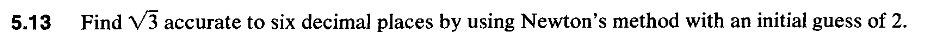

```
#define func(x) x - sqrt(3)
#define func_diff(x) 1

main ()
{

	FILE *out1;
	out1=fopen("Hornbeck_5_13_result.dat","w");

    int imax,iter;
    double x,fx,fdx,del,epsil;

    epsil = 0.000001;
    imax=1000;

    x=2;
/* 이하생략 */

/* 결과물 */
x = 1.732051, del = -0.267949
x = 1.732051, del = -0.000000
root x = 1.732051
```

## 정확도 줄여보기

```
epsil = 0.1;
    imax=100;
/* 결과 */
x = 1.732051, del = -0.267949
x = 1.732051, del = -0.000000
root x = 1.732051
```

별로 안 줄었다.

## Bisection 방법

```
#define func(x) x - sqrt(3)

main ()
{

	FILE *out1; // 파일 변수 선언
	out1=fopen("Hornbeck_5_13_bisection.dat","w");
	// 디렉토리와 디렉토리 내에서 출력할 파일 지정

    int imax,iter;
    double a,b,xc,fa,fb,fc,epsil;

    epsil = 0.00000001;
    imax=10000;

    a= 0.0;
	b= 60.0;

/* 결과 */
a = 1.732035, b = 1.732063
a = 1.732049, b = 1.732063
a = 1.732049, b = 1.732056
a = 1.732049, b = 1.732053
a = 1.732051, b = 1.732053
a = 1.732051, b = 1.732052
a = 1.732051, b = 1.732051
a = 1.732051, b = 1.732051
a = 1.732051, b = 1.732051
a = 1.732051, b = 1.732051
root x = 1.732051
```

반복 횟수가 늘었지만 여전히 정확하다.

# PROB 5.21

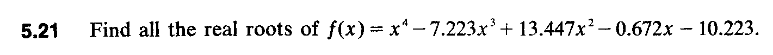

## Newton-Rapson 방법

### 첫 번째 실수 근

```
#define func(x) x*x*x*x - 7.223*x*x*x + 13.447*x*x - 0.672*x -10.223

main ()
{

	FILE *out1;
	out1=fopen("Hornbeck_5_21_result.dat","w");

    int imax,iter;
    double x,fx,xo,fxo,del,epsil;

    epsil = 0.000001;
    imax=1000;

    xo=0.01;
	x= 0.02;
	del=x-xo;
    // 생략

/* 결과 */
x = -0.698558, del = 0.096477
x = -0.712786, del = -0.014228
x = -0.713985, del = -0.001199
x = -0.713967, del = 0.000018
x = -0.713967, del = -0.000000
root x = -0.713967
```

## 두 번째 실수 근

```
#define func(x) x*x*x*x - 7.223*x*x*x + 13.447*x*x - 0.672*x -10.223

main ()
{

	FILE *out1;
	out1=fopen("Hornbeck_5_21_result.dat","w");

    int imax,iter;
    double x,fx,xo,fxo,del,epsil;

    epsil = 0.000001;
    imax=1000;

    xo=10;
	x= 10.1;

x = 8.083119, del = -2.016881
x = 7.198093, del = -0.885026
x = 6.275228, del = -0.922865
x = 5.613114, del = -0.662114
x = 5.082412, del = -0.530702
x = 4.695579, del = -0.386832
x = 4.430096, del = -0.265484
x = 4.275807, del = -0.154288
x = 4.209891, del = -0.065916
x = 4.194119, del = -0.015772
x = 4.192708, del = -0.001412
x = 4.192681, del = -0.000026
x = 4.192681, del = -0.000000
root x = 4.192681
```

이 이상 실수 근을 찾을 수는 없었음.

## Bisection 방법

```
#define func(x) x*x*x*x - 7.223*x*x*x + 13.447*x*x - 0.672*x -10.223

main ()
{

	FILE *out1; // 파일 변수 선언
	out1=fopen("Hornbeck_5_21_bisection.dat","w");
	// 디렉토리와 디렉토리 내에서 출력할 파일 지정

    int imax,iter;
    double a,b,xc,fa,fb,fc,epsil;

    epsil = 0.00000001;
    imax=10000;

    a= 0.0;
	b= 600.0;
/* 결과 */
a = 4.192681, b = 4.192681
a = 4.192681, b = 4.192681
root x = 4.192681
```

반복 횟수가 40회 정도로 증가하였으나 동일

```
a= -1000.0;
	b= 0.0;

/* 결과 */
a = -0.713967, b = -0.713967
a = -0.713967, b = -0.713967
a = -0.713967, b = -0.713967
a = -0.713967, b = -0.713967
a = -0.713967, b = -0.713967
root x = -0.713967
```

마찬가지로 반복 횟수가 40회 가량 되었으나 결과는 동일했다.

# PROB 4.14

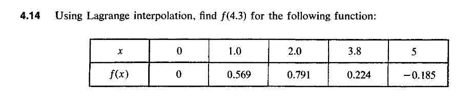

```
#define nd 5
double xd[nd]={0.0,1.0,2.0,3.8,5.0};
double fd[nd]={0, 0.569, 0.791, 0.224, -0.185};


main()
{
	FILE *out1;
	out1=fopen("Hornbeck_4_14_result","w");

    int n,i,j;
    double p,sum,f_x;
    double x,y;

   	n = nd-1;
 	x = 4.3;
 	sum=0.0;
 	f_x=0.0;

/* 결과 */
  x = 4.300000 : f(x) = -0.007153
```

# PROB 8.26

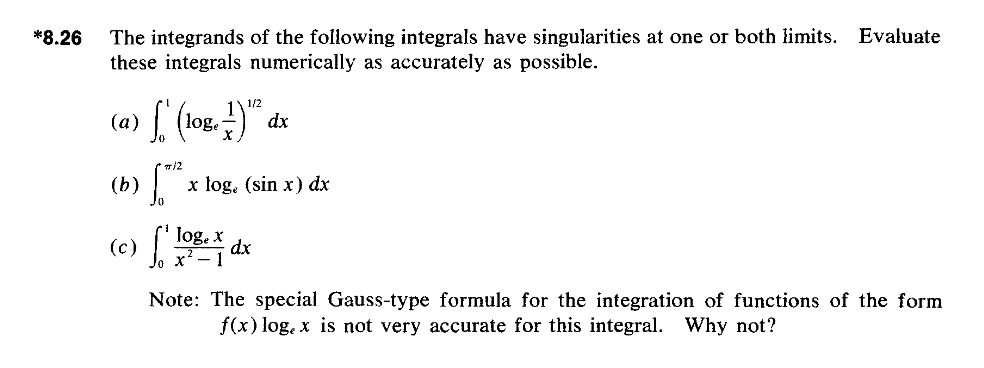

(a)의 특이점:

$$ f(0) = \left(\ln\left(\frac{1}{0}\right) \right)^{1/2} \to \infty $$

공학에선 특이점에 해당하는 점을 빼버리곤 한다.

$$ \int_{0 + \epsilon}^1 \bigg[\ln\left(\frac{1}{x}\right) \bigg]^{1/2} dx $$

## (a)번: 심슨 방법을 통한 근사

```
#define func(x) sqrt(log(1/x))

double fx[1001];

main ()
{

	FILE *out1;
	out1=fopen("Hornbeck_8_26_a.dat","w");

    int i,j,n;
    double x,x0,xn,delx,area_pre_even,area_pre_odd,area_integ;

    n=4;           /* number of span  */

    x0=0+1e-10;
    xn=1;

/* 결과 */
fx[0.000000] = 4.798526
fx[0.250000] = 1.177410
fx[0.500000] = 0.832555
fx[0.750000] = 0.536360
fx[1.000000] = 0.000000

integration using simpson method = 1.109893
```

## (b) 심슨 방법을 통한 근사

```
fx[0.000000] = -nan(ind)
fx[0.392699] = -0.377206
fx[0.785398] = -0.272198
fx[1.178097] = -0.093274
fx[1.570796] = -0.000000

integration using simpson method = -nan(ind)
```

**0** 이 특이점이다.

```
#define func(x) x * log(sin(x))

double fx[1001];

main ()
{

	FILE *out1;
	out1=fopen("Hornbeck_8_26_b.dat","w");

    int i,j,n;
    double x,x0,xn,delx,area_pre_even,area_pre_odd,area_integ;

    n=4;           /* number of span  */

    x0=0+1e-10;
    xn=3.141592 / 2;

/* 결과 */
fx[0.000000] = -0.000000
fx[0.392699] = -0.377206
fx[0.785398] = -0.272198
fx[1.178097] = -0.093274
fx[1.570796] = -0.000000

integration using simpson method = -0.317604
```

## (c) 0과 1에서 모두 발산하는 함수

```
fx[0.000000] = inf
fx[0.250000] = 1.478714
fx[0.500000] = 0.924196
fx[0.750000] = 0.657559
fx[1.000000] = -nan(ind)

integration using simpson method = -nan(ind)
```

범위를 아주 약간 더 축소하여 적분값을 구한다.

```
define func(x) log(x) / (x*x -1)

double fx[1001];

main ()
{

	FILE *out1;
	out1=fopen("Hornbeck_8_26_c.dat","w");

    int i,j,n;
    double x,x0,xn,delx,area_pre_even,area_pre_odd,area_integ;

    n=4;           /* number of span  */

    x0=0+1e-10;
    xn=1-1e-10;

/* 결과 */
fx[0.000000] = 23.025851
fx[0.250000] = 1.478714
fx[0.500000] = 0.924196
fx[0.750000] = 0.657559
fx[1.000000] = 0.500000

integration using simpson method = 2.826611
```